# Introduction

The purpose of this study is to gain a better understanding of how people perceive real-world visual scenes like this:

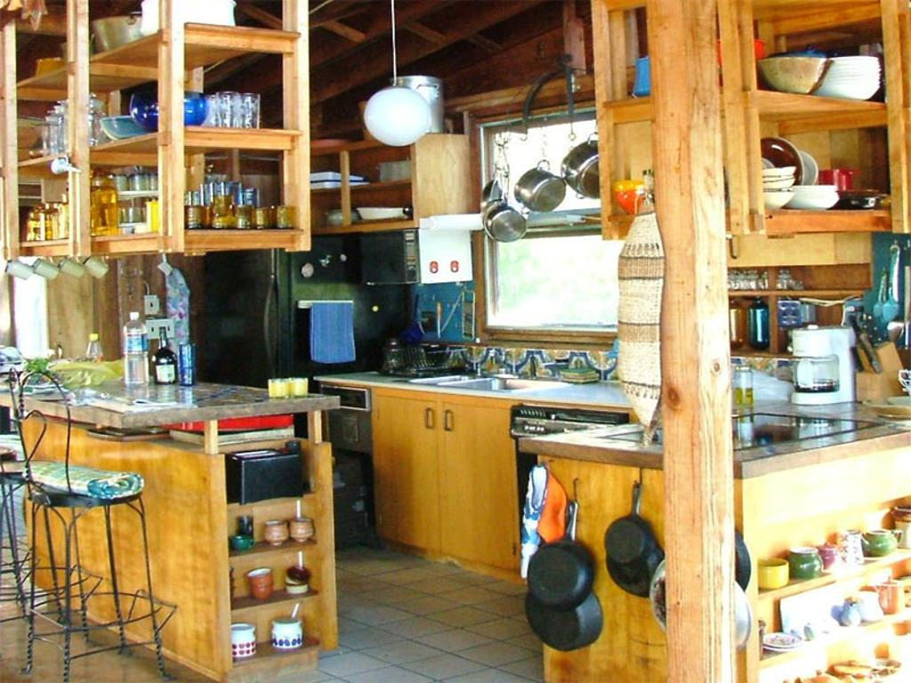

*Real-world visual scene example*

# Procedures

If you agree to take part in this study, you will be presented with a series of flickering real-world scenes. As the image flickers, a distortion will appear.

In this scene, the distortion will appear in the portion of the image circled in red.

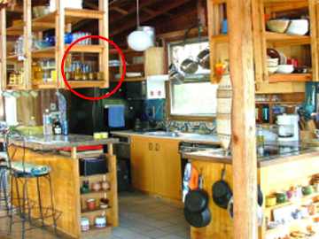

*Original image*

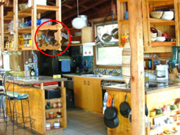

*Image with distortion*

Your task will be to find the locations of distortion as quickly as possible, using a mouse and a keyboard. As soon as you find the change, press the spacebar once to stop the images from flickering. Then, use your mouse to click on the location of the change.

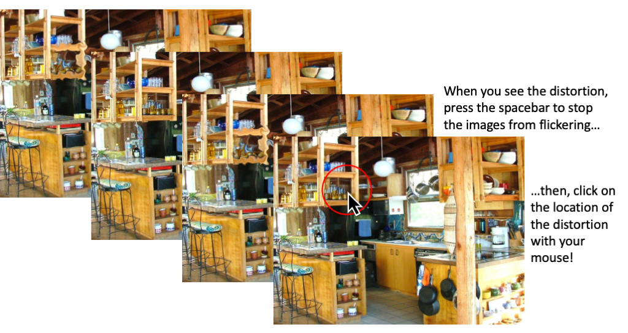

*A typical trial*

The experiment consists of 74 trials and will take approximately 30 minutes or less.  
This study will be conducted with an online Qualtrics-created survey.

# Risks/Discomforts

Risks are minimal for involvement in this study. The only foreseeable risk in this study is the possibility of boredom.

# Compensation

Participants will earn 0.5 SONA credits if they complete all 74 trials of the task. Completed items are those that are answered in good faith by a human observer. Participants continually pressing the spacebar without actually having detected any changes (i.e., ‘spamming’) will not receive credit.

# Benefits

There are no direct benefits for participants besides the SONA credit. However, it is hoped that through your participation, researchers will learn more about how we visually process complex visual scenes.

# Confidentiality

All data obtained from participants will be kept strictly confidential and will only be reported in an aggregate format (by reporting only combined results and never reporting individual ones). All questionnaires will be concealed, and no one other than then primary investigator and assistant researches listed below will have access to them. The data collected will be stored in the HIPPA-compliant, secure database until it has been deleted by the primary investigator.

# Institution Review Board (IRB) Approved

An Institutional Review Board responsible for human subjects research at the University of California, Davis reviewed this research project and found it to be acceptable according to applicable state and federal regulations and University policies designed to protect the rights and welfare of participants in research.

# Participation

Participation in this research study is completely voluntary. You have the right to withdraw at anytime. If you desire to withdraw, please close your internet browser and notify the investigator at this email: azlu@ucdavis.edu

# Questions about the Research, Participation, Concerns, or Complaints

If you have questions or concerns regarding this study, you may contact the principal investigator at this email: azlu@ucdavis.edu.